# Визуализация данных в R

Методы кластеризации

Митя Серебренников

05.11.2022

Загрузим билиотеки для работы:

```r
set.seed(42)

# install.packages(c("stats", "cluster", "factoextra", "clustertend", "dendextend", "NbClust", "fpc", "dbscan"))

library(dplyr)
library(ggplot2)
library(stats)
library(cluster)
library(factoextra)
library(clustertend)
library(dendextend)
library(NbClust)
library(fpc)
library(dbscan)
```

…

# Что такое кластеризация?

Кластеризация - разбиение наблюдений на подмножества (кластеры) таким образом, чтобы наблюдения из одного кластера были более похожи друг на друга, чем на наблюдения из других кластеров по какому-либо критерию.

Визуально это выглядит так:

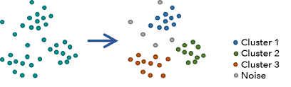

Кластеризация относится к моделям обучения без учителя. Т.е. мы можем либо не знать сколько у нас получится кластеров по итогам, либо (в ряде подметодов) контролировать их количество вручную:

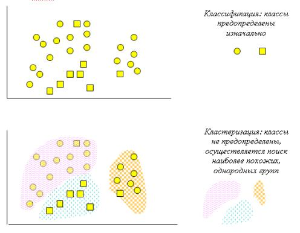

Прежде чем начать, отметим ряд особенностей кластеризации:

- Не существует универсального алгоритма кластеризации. Алгоритмов достаточно много. Сегодня мы расммотрим четыре самых популярных из них;
- Нужно быть осторожным с интерпретацией кластерного анализа - далеко не всегда можно искренне считать, что получившиеся кластеры отражают структуру данных;
- Данные должны быть нормированы
- Отдельные кластеры можно выбраковывать
- Cостав и количество кластеров зависит от выбираемых переменных. Изменение переменных влияет на кластеры
- Данные о кластеризации полезны, если вы после успешной кластеризации будете присваивать данным переменную с номером кластера и работать с ней дальше при анализе.

…

Загрузим датасеты:

```r
# Ирисы
iris <- iris |>
  select(is.numeric)

# Системы здравоохранения
hs <- read.csv('Health_systems.csv')
rownames(hs) <- hs$World_Bank_Name
# Уберём дамми переменные и переменную с большим количеством миссингов. Оставим только полностью заполненные строки
hs_num <- hs |>
  select(-c(Country_Region, Province_State, World_Bank_Name, `Completeness_of_death_reg_2008.16`)) |>
  na.omit()

# Стандартизируем объекты для подсчёта и переведём их матрицу
iris_scaled <- scale(iris)
hs_scaled <- scale(hs_num)
```

# Иерархическая кластеризация (hierarchical clustering)

В основном к ней относится два вида алгоритмов:

- Agglomerative Nesting (agnes) - каждое наблюдение находит ближайшее себе по дистанции до него (по каждой из переменных). После нахождения первого соседа, начинатся следующий шаг, когда образовавшийся мини-кластер ищет другие ближайшие к ним кластеры/наблюдения. Так прохожит несколько шагов, пока все наблюдения не сольются в один кластер.
- Divisive Analysis Clustering (diana) - обратный способ. Мы отталкиваемся от одного кластера всех наблюдений и ищем непохожие друг на друга наблюдения и делим один кластер на два. Затем алгоритм продолжается до конца.

Посмотрим визуально:

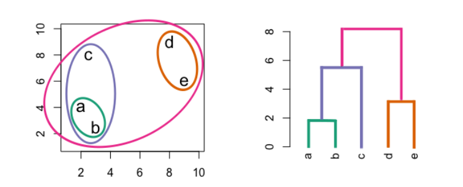

“Длинна” дистанции обозначает меру схожести/разницы наблюдений - Высоту/Height (Крестовский остров ближе к Институт биоинформатики чем к Кудрово).

…

Разница между agnes и diana:

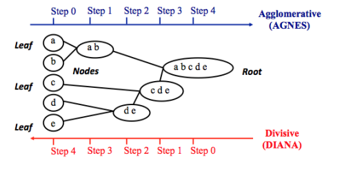

Мы будем рассматривать первый тип.

…

### Как это работает?

1. Создаём матрицу дистанций

```r
hs_dist <- dist(hs_scaled,
                       method = "euclidean")
as.matrix(hs_dist)[1:6, 1:6]
```

```
##             Afghanistan  Albania  Algeria Argentina  Armenia Australia
## Afghanistan    0.000000 3.631491 4.844901  5.995297 4.209154  7.496611
## Albania        3.631491 0.000000 1.862557  3.390808 3.043501  5.315160
## Algeria        4.844901 1.862557 0.000000  2.044730 4.217423  4.859874
## Argentina      5.995297 3.390808 2.044730  0.000000 4.458793  4.087963
## Armenia        4.209154 3.043501 4.217423  4.458793 0.000000  5.683430
## Australia      7.496611 5.315160 4.859874  4.087963 5.683430  0.000000
```

```r
iris_dist <- dist(iris_scaled,
                  method = "euclidean")
as.matrix(iris_dist)[1:6, 1:6]
```

```
##           1         2         3         4         5         6
## 1 0.0000000 1.1722914 0.8427840 1.0999999 0.2592702 1.0349769
## 2 1.1722914 0.0000000 0.5216255 0.4325508 1.3818560 2.1739229
## 3 0.8427840 0.5216255 0.0000000 0.2829432 0.9882608 1.8477070
## 4 1.0999999 0.4325508 0.2829432 0.0000000 1.2459861 2.0937597
## 5 0.2592702 1.3818560 0.9882608 1.2459861 0.0000000 0.8971079
## 6 1.0349769 2.1739229 1.8477070 2.0937597 0.8971079 0.0000000
```

**Основные типы дистанций**:

- “euclidean” - Евклидова дистанция. Прямой путь между точками в евклидовом пространстве.
- “manhattan” - Манхэттенская дистанция. Сумма модулей разностей координат двух точек.
- “pearson”/“spearman”/“kendall” - Корреляционные дистанции. Схожесть между наблюдениями высчитывается по корреляции их характеристик (даже если наблюдаемые значения могут сильно отличаться друг от друга с точки зрения евклидова расстояния). Расстояние между двумя объектами равно 0, когда они идеально скоррелированы. Используется при кластеризации генов. Здесь необходимо не забывать разную специфику методов корреляции.
- “cosine” - Дистанция по косинусному расстоянию между точками в многомерном пространстве. Не присутствует в базовом функционале dist(), но легко прописывается вручную, либо из пакетов lsa::cosine(), stylo::cosine.dist(). (в моём мире) Используется для предобработки текстов для анализа (NLP).
- “gower” - Для смешанных типов данных (с наличием дамми, факторов и проч.) используется дистанцию Говера (“gower”) из пакета cluster. Пример:

```r
# Предустановленный датасет характеристик 18 видов цветов
flower
```

| V1 | V2 | V3 | V4 | V5 | V6 | V7 | V8 |
| --- | --- | --- | --- | --- | --- | --- | --- |
| 0 | 1 | 1 | 4 | 3 | 15 | 25 | 15 |
| 1 | 0 | 0 | 2 | 1 | 3 | 150 | 50 |
| 0 | 1 | 0 | 3 | 3 | 1 | 150 | 50 |
| 0 | 0 | 1 | 4 | 2 | 16 | 125 | 50 |
| 0 | 1 | 0 | 5 | 2 | 2 | 20 | 15 |
| 0 | 1 | 0 | 4 | 3 | 12 | 50 | 40 |
| 0 | 0 | 0 | 4 | 3 | 13 | 40 | 20 |
| 0 | 0 | 1 | 2 | 2 | 7 | 100 | 15 |
| 1 | 1 | 0 | 3 | 1 | 4 | 25 | 15 |
| 1 | 1 | 0 | 5 | 2 | 14 | 100 | 60 |

[output cut: 8 more lines]

```r
flower_gower <- cluster::daisy(flower,
                               metric = "gower")
```

- etc. - [Здесь](https://rstudio-pubs-static.s3.amazonaws.com/599072_93cf94954aa64fc7a4b99ca524e5371c.html) также хорошо разобраны отличия методов
2. Высчитываем дендрограмму кластеров.

```r
hs_dist.hc <- hclust(d = hs_dist,
                     method = "ward.D2")
```

method - аналог функции связи, т.е. каким образом мы объединяем данные в кластеры. К основным относятся:

| **Method** | **Process** | **Result** |
| --- | --- | --- |
| `single` | Measures the distance between the two closest points in each cluster | Generally better for identifying outliers that don’t cluster well |
| `complete` | Measures the distance between the two most distant points in each cluster | Generally produces tighter clusters |
| `centroid` | Measures the distance between the center of each cluster | Generally works better for data with fewer similarities |
| `median` | Measures the median distance between each cluster’s median point | Similar to centroid, but weighted toward where the majority of observations are located |
| `average` | Measures the average (mean) distance between each observation in each cluster, weighted by the number of observations in each cluster | Generally similar to complete linkage, better at incorporating outliers |
| `mcquitty` | Similar to average, but does not take number of points in the cluster into account. | Generally similar to single linkage |
| `ward.D` | Minimizes within cluster variance (sum of errors). Clusters are combined according to smallest between cluster distance. | Generally produces more compact clusters |
| `ward.D2` | Same as ward.D, but the differences are squared (sum of squared errors) | Emphasizes the differences identified in ward.D, making clusters easier to differentiate |

3. Визуализируем

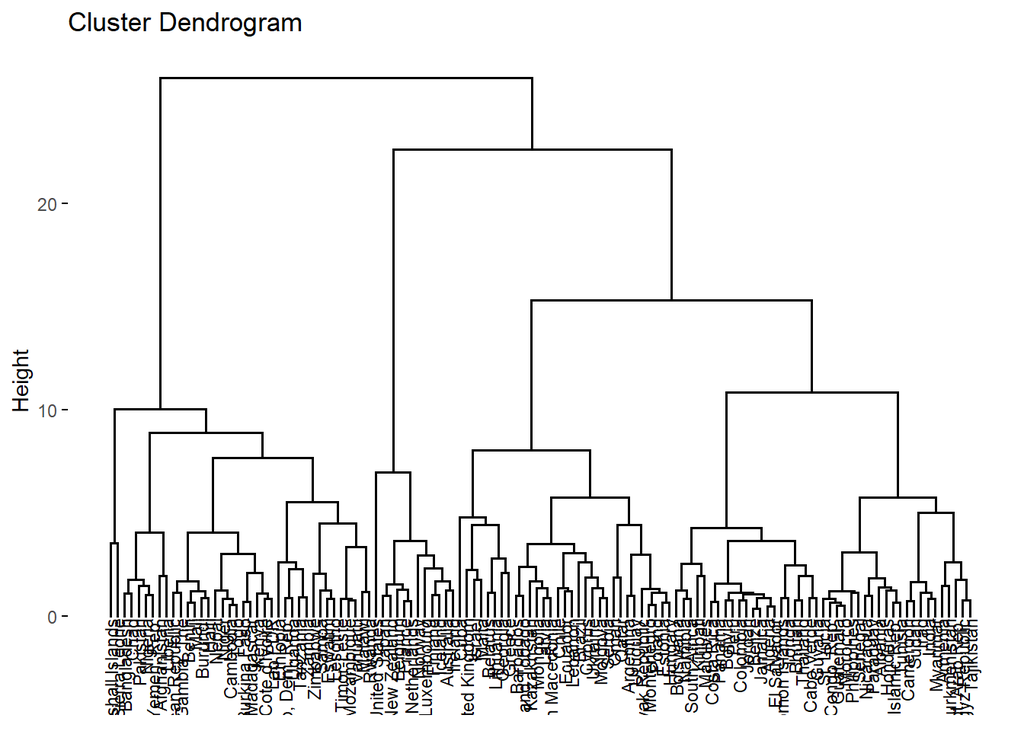

```r
fviz_dend(hs_dist.hc,
          cex = 0.6) # cex() - размер лейблов
```

4. Оценить качество кластеризации.

*Метрики оценки качества будут в завершении занятия*

5. Перебрав несколько вариантов метрик и методов останавливаемся на самом лучшем

…

## Работа с дендрограмой

```r
hs_dist.hc_k3 <- cutree(hs_dist.hc,
                          k = 3) # Создаём вектор принадлежности к кластерам

# Смотрим результат
head(hs_dist.hc_k3, n = 4)
```

```
## Afghanistan     Albania     Algeria   Argentina
##           1           2           2           2
```

```r
table(hs_dist.hc_k3)
```

```
## hs_dist.hc_k3
##  1  2  3
## 38 74 12
```

Можем установить линию тршэшхолда для кластеров вручную:

```r
hs_dist.hc_h20 <- cutree(hs_dist.hc, h=20)  # Создаём вектор принадлежности к кластерам

# Смотрим результат
table(hs_dist.hc_h20)
```

```
## hs_dist.hc_h20
##  1  2  3
## 38 74 12
```

Варианты визуализации:

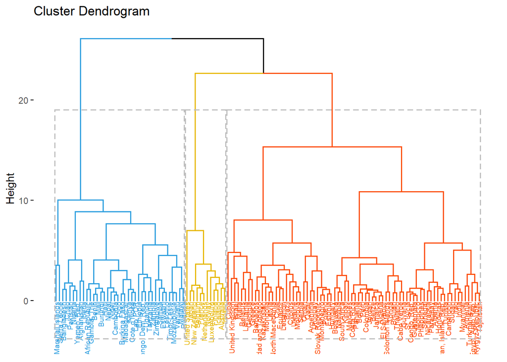

```r
fviz_dend(hs_dist.hc,
          k = 3, # Задаём число кластеров
          cex = 0.5, # Задаем размер лейблов
          k_colors = c("#2E9FDF", "#E7B800", "#FC4E07"),
          color_labels_by_k = TRUE, # Соотнести цвета с кластерами
          rect = TRUE # Добавить "квадратик" вокруг групп
)
```

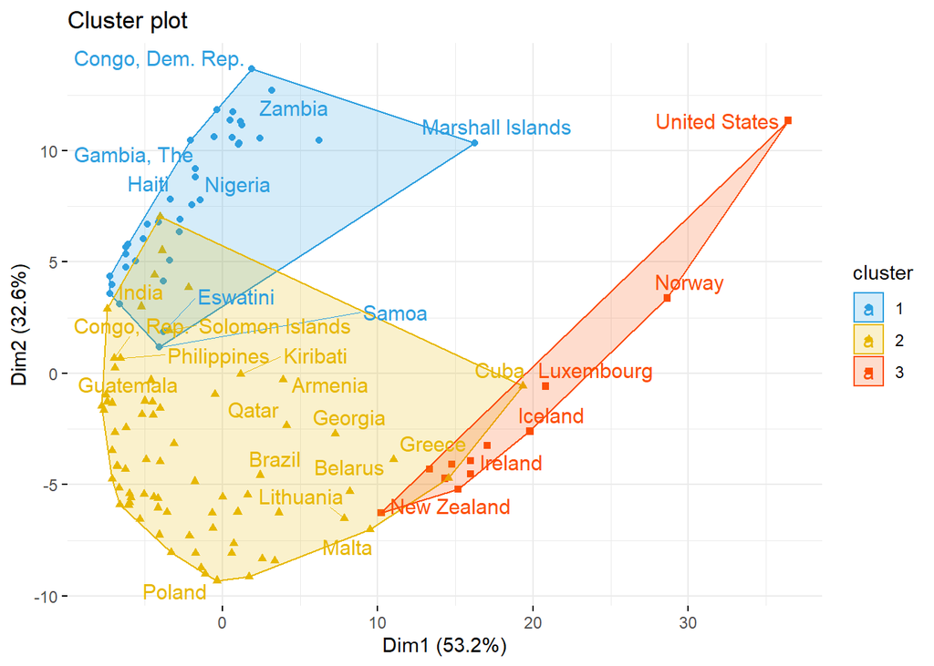

```r
fviz_cluster(list(data = hs_dist, cluster = hs_dist.hc_h20),
             palette = c("#2E9FDF", "#E7B800", "#FC4E07"),
             ellipse.type = "convex", # Объединить кластеры элипсом
             repel = TRUE, # Избежать наслоения лейблов
             show.clust.cent = FALSE, # Показывать центр кластера
             ggtheme = theme_minimal())
```

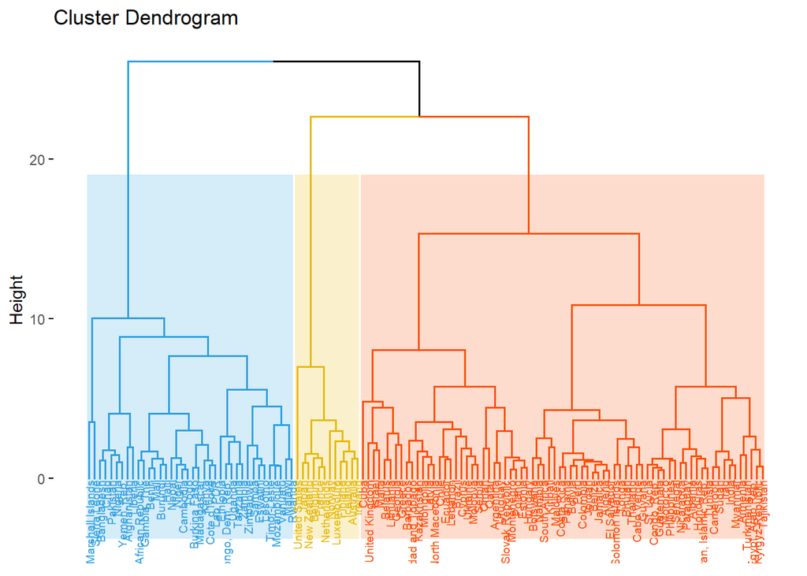

```r
fviz_dend(hs_dist.hc,
          k = 3,
          cex = 0.5,
          k_colors = c("#2E9FDF", "#E7B800", "#FC4E07"),
          color_labels_by_k = TRUE,
          rect = TRUE,
          rect_border = c("#2E9FDF", "#E7B800", "#FC4E07"), # Добавить цвет для границы "квадратика"
          rect_fill = TRUE) # Закрасить внутреннюю часть "квадратика"
```

4. Горизонтальная дендрограмма

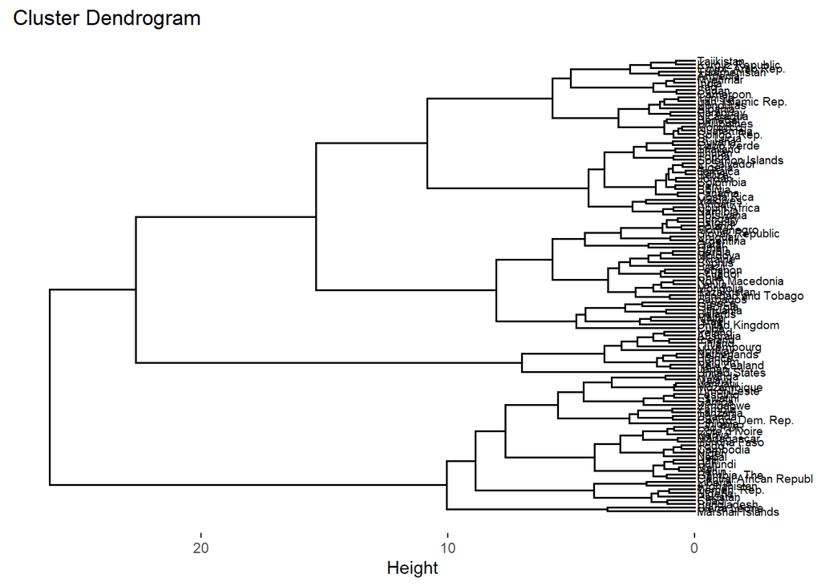

```r
fviz_dend(hs_dist.hc,
          cex = 0.5,
          horiz = TRUE)
```

5. Раскрашиваем горизонтальную дендрограмму

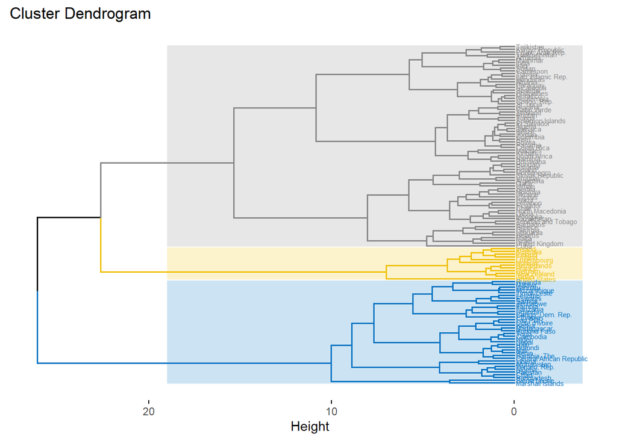

```r
fviz_dend(hs_dist.hc,
          k = 3,
          cex = 0.4,
          horiz = TRUE,
          k_colors = "jco",
          rect = TRUE,
          rect_border = "jco",
          rect_fill = TRUE)
```

6. Круговая дендрограмма

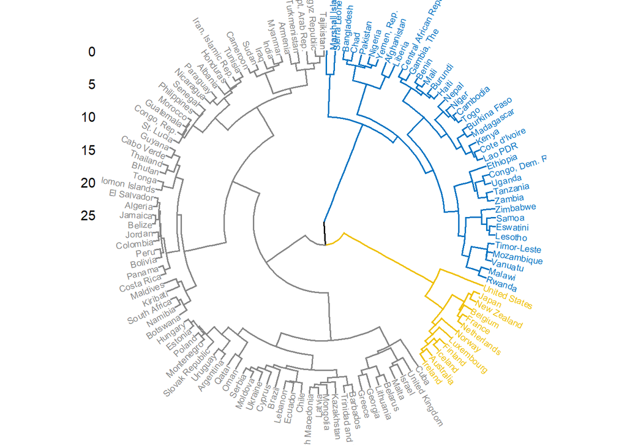

```r
fviz_dend(hs_dist.hc,
          cex = 0.5,
          k = 3,
          k_colors = "jco",
          type = "circular")
```

7. Древовидная дендрограмма

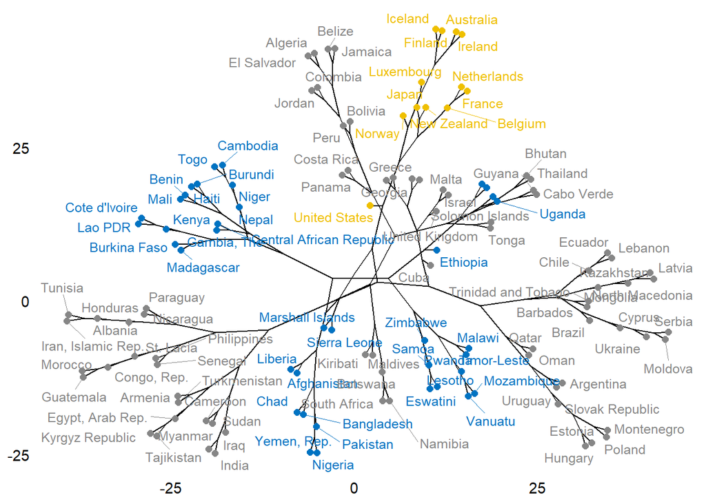

```r
fviz_dend(hs_dist.hc,
          k = 3,
          k_colors = "jco",
          type = "phylogenic",
          repel = TRUE) # Избежать наслоения лейблов
```

8. Приближение на участок дендрограммы

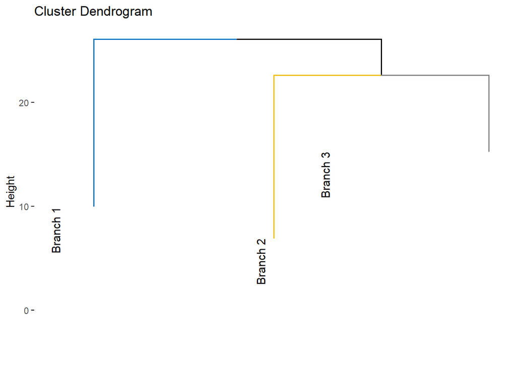

```r
hc_plot <- fviz_dend(hs_dist.hc,
                       k = 3,
                       cex = 0.5,
                       k_colors = "jco"
)
dend_data <- attr(hc_plot,
                  "dendrogram") # Извлекаем данные по дендрограмме

# Разрезаем по высоте h = 20
dend_cuts <- cut(dend_data, h = 20)
# Смотрим верхнюю часть графика
fviz_dend(dend_cuts$upper)
```

Нижнюю мы сразу посмотреть не можем, т.к. мы теперь имеем дело с 3 независимыми дендрограммами…

9. Выведение отдельной ветви дендрограммы

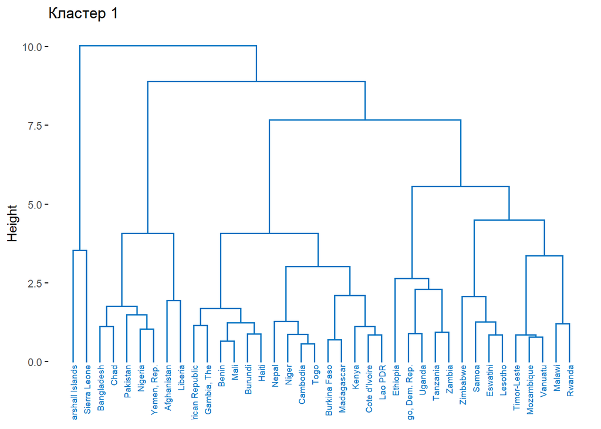

```r
fviz_dend(dend_cuts$lower[[1]],
          main = "Кластер 1")
```

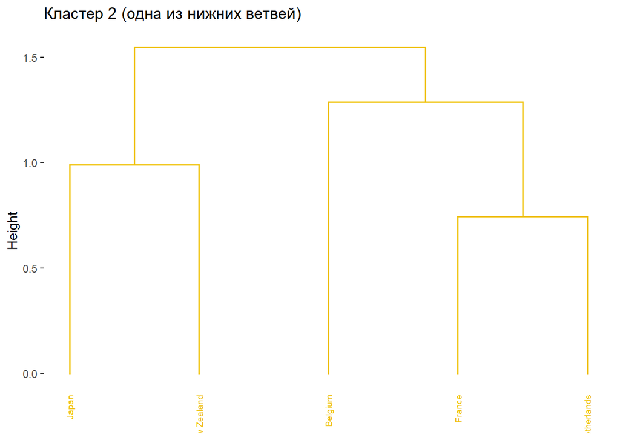

```r
# Plot subtree 2
fviz_dend(dend_cuts[["lower"]][[2]][[2]][[1]],
          main = "Кластер 2 (одна из нижних ветвей)")
```

## Как выбрать количество кластеров?

Метрики выбора числа кластеров будут описаны в разделе Partitioning Clustering

## Альтернативный способ анализа с помощью пакета cluster

cluster представляет также представляет удобный функционал для работы с деревьями. Его пример ниже:

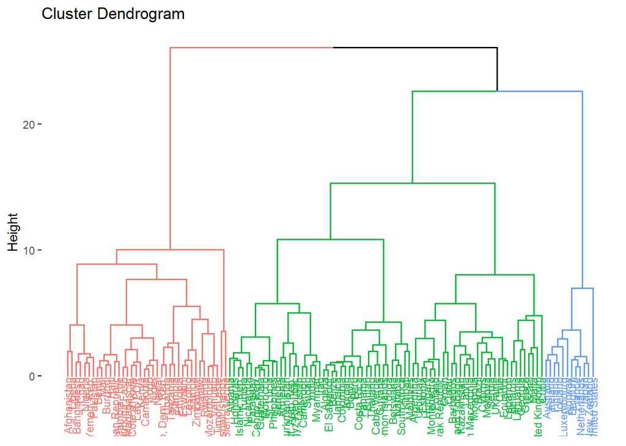

```r
library(cluster)
# Agnes
hs.agnes <- agnes(x = hs_dist,
                   stand = F, # Стандартизировать данные?
                   metric = "euclidean",
                   method = "ward" )

# Diana
hs.diana <- diana(x = hs_dist,
                   stand = F,
                   metric = "euclidean")

fviz_dend(hs.agnes, cex = 0.6, k = 3)
```

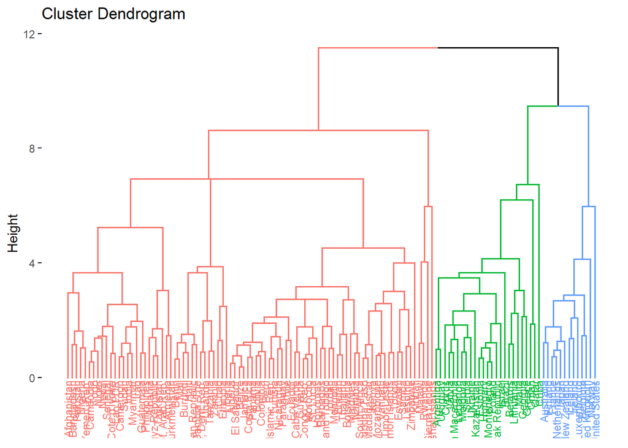

```r
fviz_dend(hs.diana, cex = 0.6, k = 3)
```

# Partitioning Clustering

## kMeans

Общая идея:

1. Случайным образом задаём n-ое количество точек. Число n выбираем сами (как это сделать - ниже). Эти точки называем центроидами - геометрическими центрами кластеров
2. Для всех точек-наблюдений определяем, к какому центроиду они ближе. Благодаря этому, мы образуем кластер вокруг центроида
3. Перемещаем каждый центроид в геометрический центр точек его кластера (изначально же наблюдения включались просто по факту того, что центроид был ближе, а не “центральнее”)
4. Пересчитываем точки, которые в таком, новом положении центроида попали в его кластер
5. Курсируем между шагом 3 и 4 до тех пор, пока в результате нового движения ни одна из точек не поменяет принадлежность к какому-либо кластеру

Как это выглядит визуально:

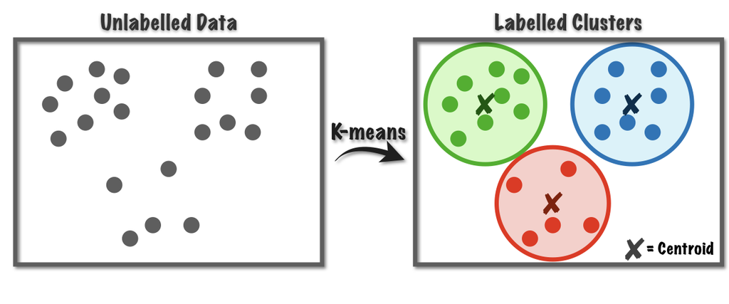

Посмотрим движение центроида на [видео](https://www.youtube.com/watch?v=nXY6PxAaOk0&ab_channel=JohanHagelb%C3%A4ck).

…

А можно ли доверять такому способу кластеризации k-means?

Нет, всегда надо быть на чеку. Разберёмся почему на [этом сайте](https://www.naftaliharris.com/blog/visualizing-k-means-clustering/).

…

Считать kMeans просто:

```r
hs_kmean <- kmeans(hs_num,
                          centers = 3, # Количество центроидов-кластеров
                          iter.max = 10, # Максимальное количество итераций-шагов центроидов
                          nstart = 35) # Какое количество центроидов сгенерировать в начале? Потом автоматически алгоритм сократит их до числа centers, оставив только лучшие. Рекомендуется ставить между 25 и 50, чтобы найти стабильное решение

head(hs_kmean)
```

```
## $cluster
##              Afghanistan                  Albania                  Algeria
##                        1                        1                        1
##                Argentina                  Armenia                Australia
##                        2                        1                        3
##               Bangladesh                 Barbados                  Belarus
##                        1                        2                        1
##                  Belgium                   Belize                    Benin
##                        3                        1                        1
##                   Bhutan                  Bolivia                 Botswana
##                        1                        1                        1
##                   Brazil             Burkina Faso                  Burundi
##                        2                        1                        1
##               Cabo Verde                 Cambodia                 Cameroon
##                        1                        1                        1
## Central African Republic                     Chad                    Chile
##                        1                        1                        2
##                 Colombia         Congo, Dem. Rep.              Congo, Rep.
##                        1                        1                        1
##               Costa Rica            Cote d'Ivoire                     Cuba
##                        2                        1                        2
##                   Cyprus                  Ecuador         Egypt, Arab Rep.
##                        2                        1                        1
##              El Salvador                  Estonia                 Eswatini
##                        1                        2                        1
##                 Ethiopia                  Finland                   France
##                        1                        3                        3
##              Gambia, The                  Georgia                   Greece
##                        1                        1                        2
##                Guatemala                   Guyana                    Haiti
##                        1                        1                        1
##                 Honduras                  Hungary                  Iceland
##                        1                        2                        3
##                    India       Iran, Islamic Rep.                     Iraq
##                        1                        2                        1
##                  Ireland                   Israel                  Jamaica
##                        3                        2                        1
##                    Japan                   Jordan               Kazakhstan
##                        3                        1                        1
##                    Kenya                 Kiribati          Kyrgyz Republic
```

[output cut: 64 more lines]

```
## 1                             18.91477                          76.36818
## 2                             58.14348                          99.33913
## 3                             69.90769                         100.00000
##
## $totss
## [1] 667604995
##
## $withinss
## [1] 12948603 15728137 67336940
##
## $tot.withinss
## [1] 96013681
##
## $betweenss
## [1] 571591314
```

### Как выбрать количество кластеров/центроидов?

#### Метод локтя

Возьмем метрику подсчета суммы квадратов (total within sum of squares) каждого из кластеров.

После того, как мы кластеризовали данные, мы можем посмотреть какое значение будет получаться если сложить все дистанции от центроида до всех наблюдений в кластере. Дальше, мы можем добавлять по одному новому кластеру и смотреть как падает расстояние…

**А оно всегда будет падать, понимаете почему?**

И здесь может сложиться две ситуации, которые хорошо иллюстрируются в сравнении данных по системам здравоохранения с данными ирисов. Посчитаем как будут падать суммы квадратов для каждого датасета с возрастанием числа кластеров:

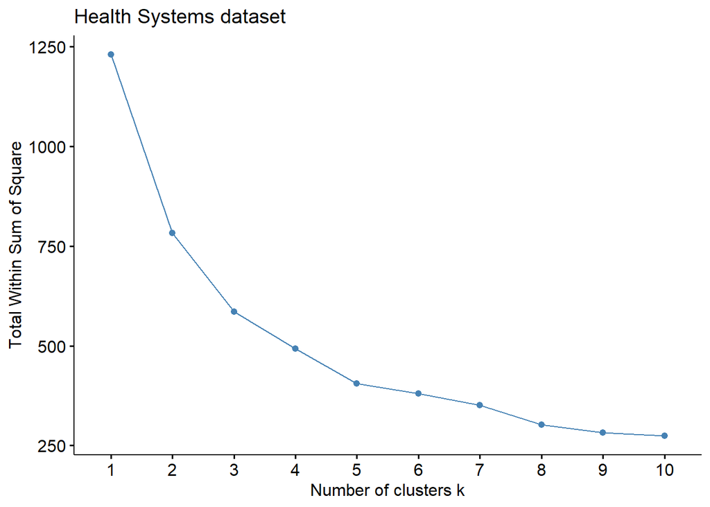

```r
# hs
fviz_nbclust(hs_scaled, kmeans, method = "wss") +
  ggtitle('Health Systems dataset')
```

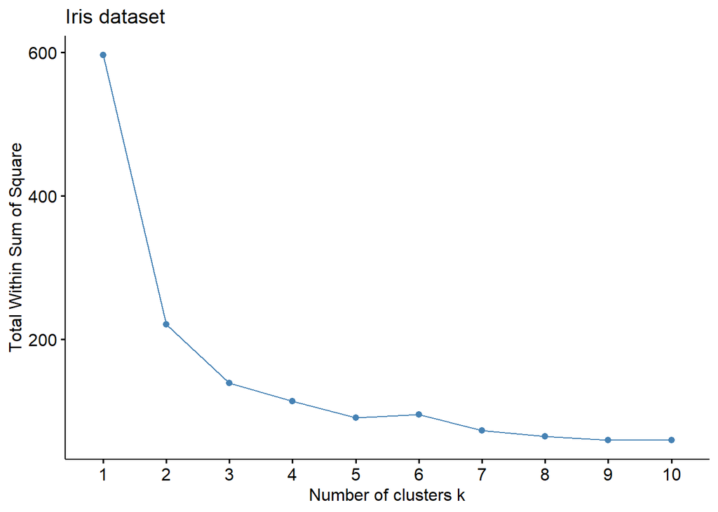

```r
# iris
fviz_nbclust(iris_scaled, kmeans, method = "wss") +
  ggtitle('Iris dataset')
```

Посмотрите на разницу. Во втором случае после 3го кластера “обрушение” значения сумм квадратов прекращается. Это значит, что именно это число - оптимально для kMeans. Через поиск таких углов и находbтся нужное количество кластеров. Сами углы называются “локти” (elbow), а метод - **метод локтя**.

Наличие локтя говорит о наличии выраженных кластеров в данных. Но вот в случае систем здравоохранения мы имеем гладкую линию - выраженных кластеров нет, всё становится сложнее. Стоит прибегнуть к другим методам оценки

#### Коэффициент силуэта (silhouette)

Коэффициент силуэта подсчитывает расстояние между точкой и другими точками её кластера и соседних кластеров.  
Огрубляя, можно сказать, что значение силуэта показывает, насколько плотно в среднем в каждом кластере одна точка окружена другими относящимися к тому же кластеру. Т.е. если кластер сильно разряжен (что говорит о том, что на самом деле в действительности он может кластером и не быть), то значение будет низким (-1), если наоборот, все наблюдения кучкуются вокруг друг друга, а дистанция до других кластеров велика, то значение будет высоким (1)

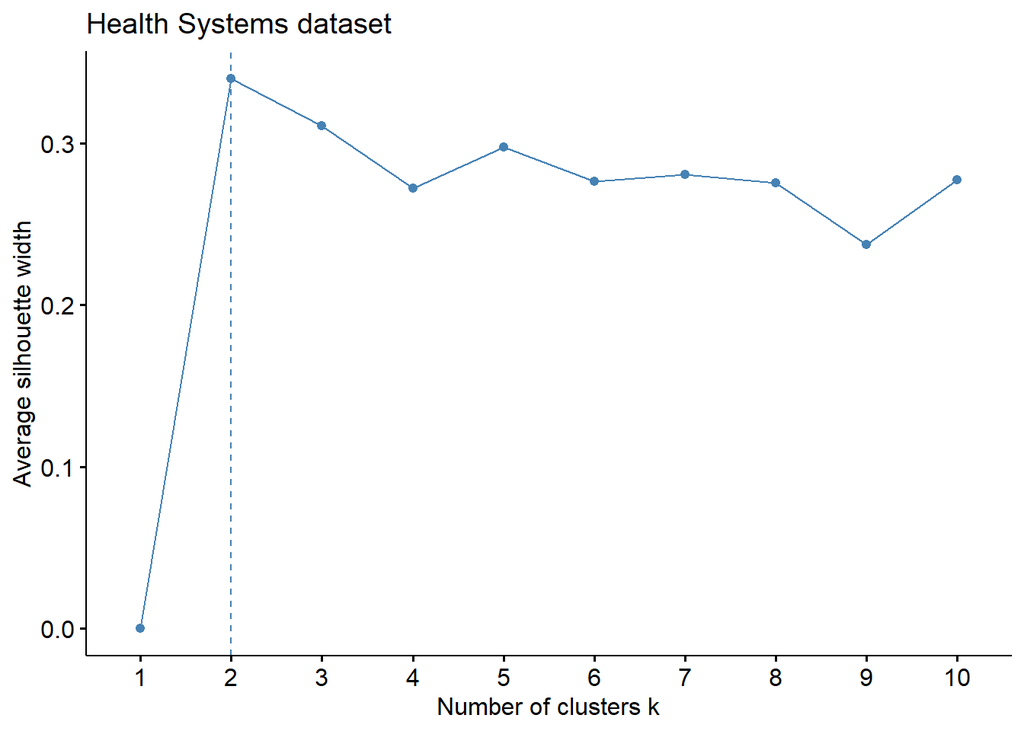

```r
# hs
fviz_nbclust(hs_scaled, kmeans, method = "silhouette") +
  ggtitle('Health Systems dataset')
```

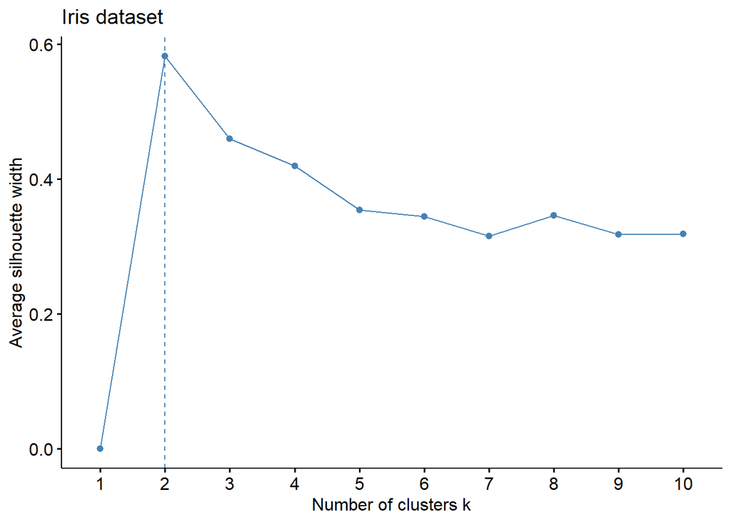

```r
# iris
fviz_nbclust(iris_scaled, kmeans, method = "silhouette") +
  ggtitle('Iris dataset')
```

#### Gap statistics

Измеряет, насколько отличается распределение на кластеры наших данных от рандомных стандартизированных данных той же размерности работает через бутстрэп. Хорошо схватывает данные с ярко выраженными кластерами.

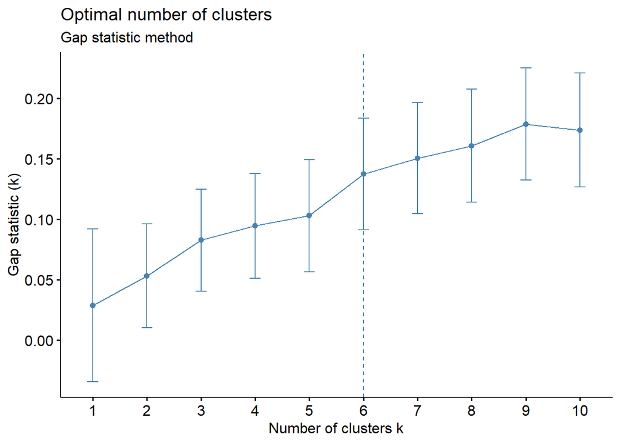

```r
fviz_nbclust(USArrests,
             kmeans,
             nstart = 25,
             method = "gap_stat",
             nboot = 50)+ # Количество выборок для бутстрепа. Используется только для определения количества кластеров
  labs(subtitle = "Gap statistic method")
```

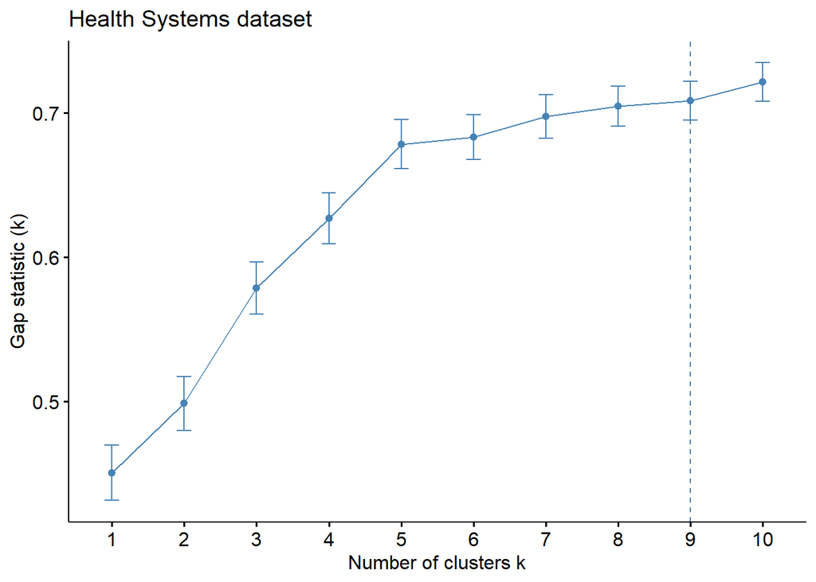

```r
# hs
fviz_nbclust(hs_scaled,
             kmeans,
             nstart = 25,
             method = "gap_stat",
             nboot = 50) + # Количество выборок для бутстрепа.
  ggtitle('Health Systems dataset')
```

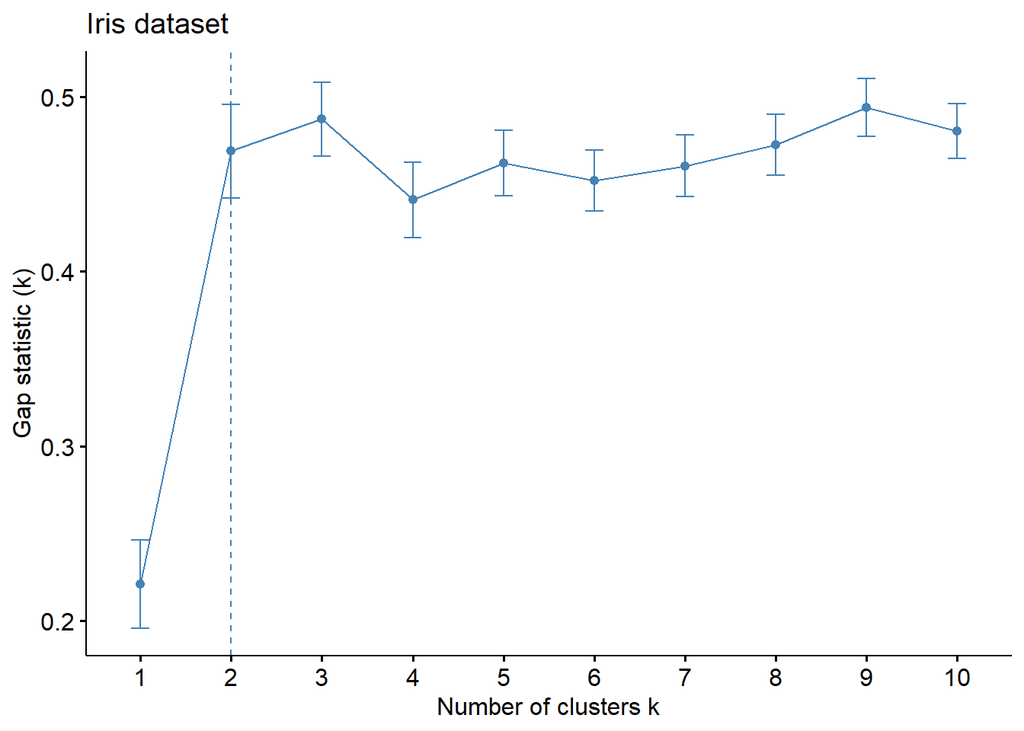

```r
# iris
fviz_nbclust(iris_scaled,
             kmeans,
             nstart = 25,
             method = "gap_stat",
             nboot = 50) + # Количество выборок для бутстрепа.
  ggtitle('Iris dataset')
```

#### Перебор метрик

Метрик много и есть функции их перебора с выводом лучшего числа кластеров по сумме оценок:

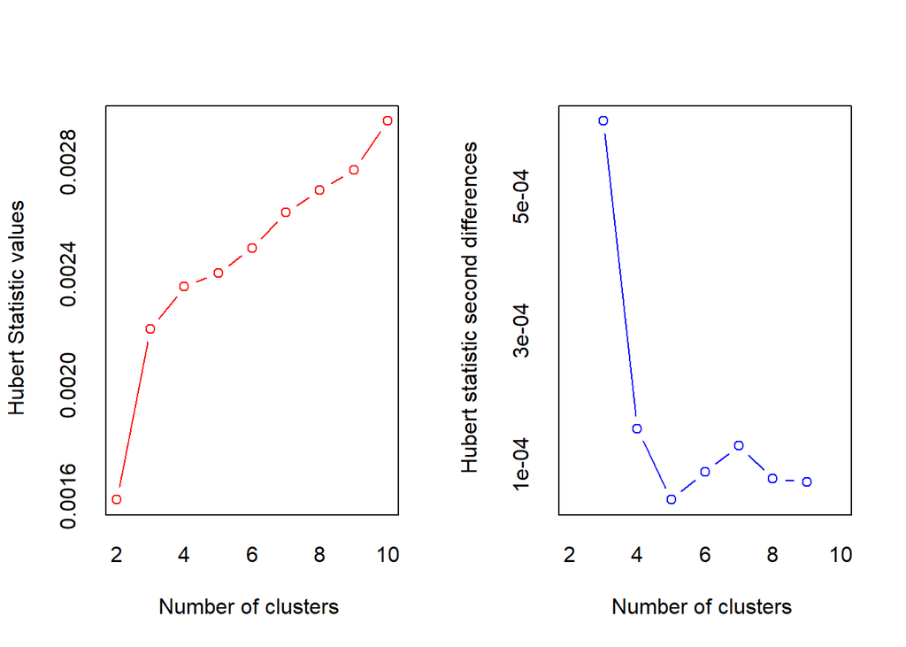

```
## *** : The Hubert index is a graphical method of determining the number of clusters.
##                 In the plot of Hubert index, we seek a significant knee that corresponds to a
##                 significant increase of the value of the measure i.e the significant peak in Hubert
##                 index second differences plot.
##
```

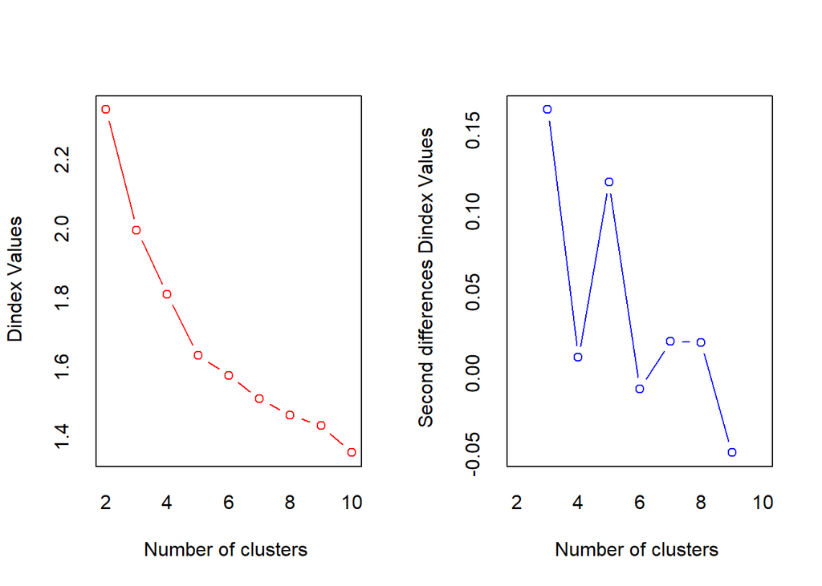

```
## *** : The D index is a graphical method of determining the number of clusters.
##                 In the plot of D index, we seek a significant knee (the significant peak in Dindex
##                 second differences plot) that corresponds to a significant increase of the value of
##                 the measure.
##
## * Among all indices:
## * 3 proposed 2 as the best number of clusters
## * 9 proposed 3 as the best number of clusters
## * 3 proposed 5 as the best number of clusters
## * 1 proposed 6 as the best number of clusters
## * 2 proposed 7 as the best number of clusters
## * 1 proposed 8 as the best number of clusters
## * 1 proposed 9 as the best number of clusters
## * 3 proposed 10 as the best number of clusters
##
##                    ***** Conclusion *****
##
## * According to the majority rule, the best number of clusters is  3
##
##
```

```r
nb <- NbClust(hs_scaled,
              distance = "euclidean",
              min.nc = 2, # Минимальное число кластеров
              max.nc = 10, # Максимальное
              method = "kmeans")
```

```
## Among all indices:
## ===================
## * 2 proposed  0 as the best number of clusters
## * 1 proposed  1 as the best number of clusters
## * 3 proposed  2 as the best number of clusters
## * 9 proposed  3 as the best number of clusters
## * 3 proposed  5 as the best number of clusters
## * 1 proposed  6 as the best number of clusters
## * 2 proposed  7 as the best number of clusters
## * 1 proposed  8 as the best number of clusters
## * 1 proposed  9 as the best number of clusters
## * 3 proposed  10 as the best number of clusters
##
## Conclusion
## =========================
## * According to the majority rule, the best number of clusters is  3 .
```

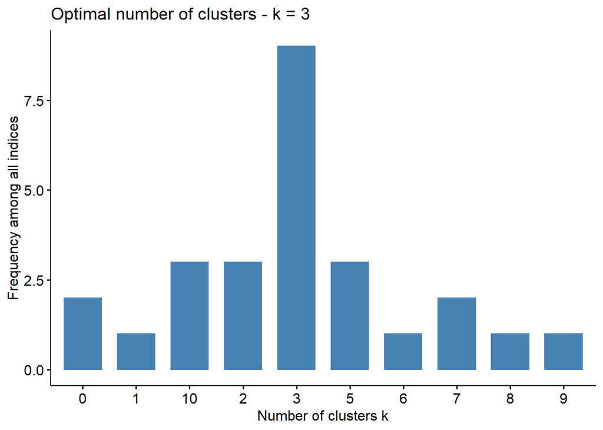

```r
fviz_nbclust(nb)
```

…

Итого останавливаемся на 3 кластерах. Визуализируем:

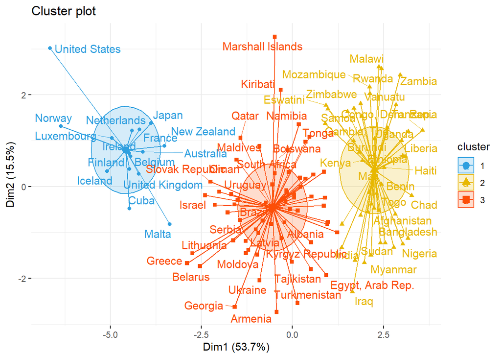

```r
hs_scaled_kmean3 <- kmeans(hs_scaled, 3, nstart = 25)

fviz_cluster(hs_scaled_kmean3, data = hs_scaled,
                          palette = c("#2E9FDF", "#E7B800", "#FC4E07"),
             ellipse.type = "euclid",
             star.plot = T,  # Проводим линии принадлежности точек к центроиду кластера
             repel = TRUE,
             ggtheme = theme_minimal())
```

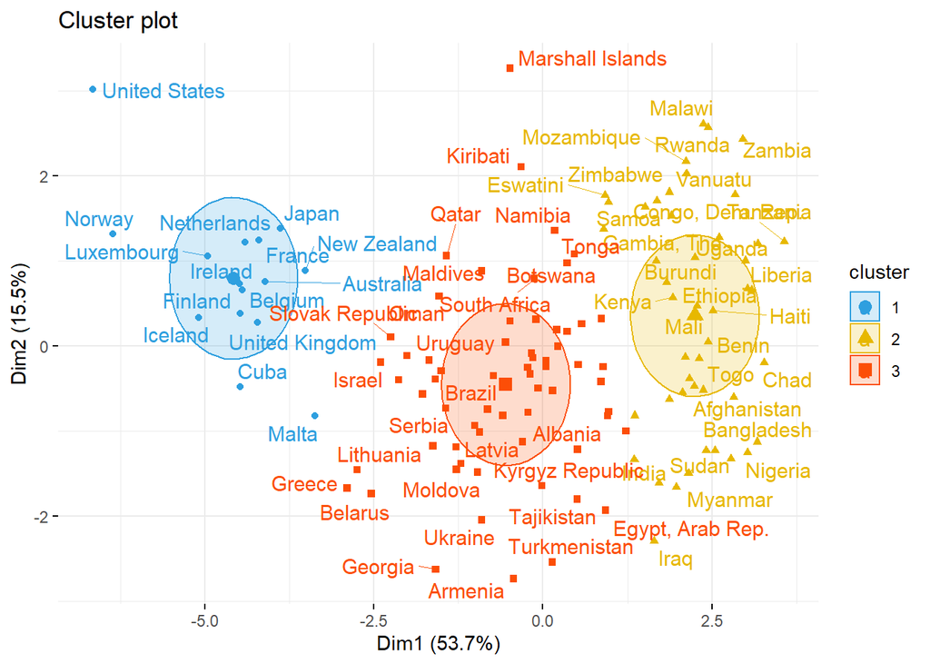

```r
# Без линий
fviz_cluster(hs_scaled_kmean3, data = hs_scaled,
                          palette = c("#2E9FDF", "#E7B800", "#FC4E07"),
             ellipse.type = "euclid",
             star.plot = F,  # Не проводим линии
             repel = TRUE,
             ggtheme = theme_minimal())
```

## K-Medoids | Partitioning Around Medoids (PAM)

То же самое что и kMeans, но теперь считаем не по средним значениям, а по медианному наблюдению в кластере.

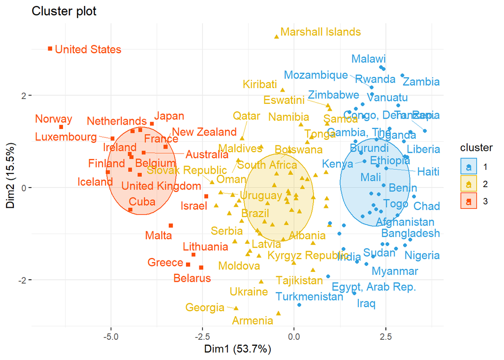

```r
hs.pam <- pam(hs_scaled,
               k = 3,
               metric = "euclidean",
               stand = FALSE) # Стандартизировать?

fviz_cluster(
  hs.pam,
  data = hs_scaled,
  palette = c("#2E9FDF", "#E7B800", "#FC4E07"),
  ellipse.type = "euclid",
  star.plot = F,
  # Не проводим линии
  repel = TRUE,
  ggtheme = theme_minimal()
)
```

```r
# Сравним kMean и kMedoids
table(hs.pam$clustering,
      hs_scaled_kmean3$cluster)
```

```
##
##      1  2  3
##   1  0 43  4
##   2  0  3 55
##   3 15  0  4
```

**НО,есть одна серьёзная проблема с разобранными методами**

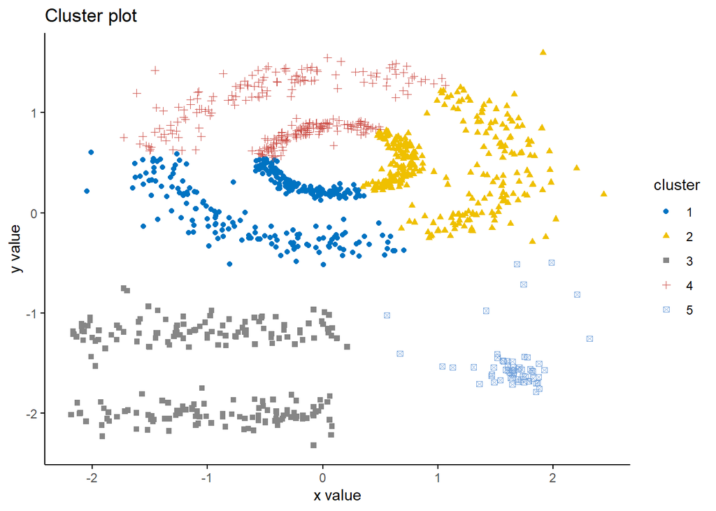

```r
data(multishapes)
df <- multishapes[, 1:2]
km.res <- kmeans(df, 5, nstart = 25)
fviz_cluster(km.res, df, geom = "point",
             ellipse= FALSE, show.clust.cent = FALSE,
             palette = "jco", ggtheme = theme_classic())
```

**Классические алгоритмы не чувствительны к кластерам сложной формы и нелинейным связям внутри. Для таких задач нужен другой метод**